NB-FOXR2 project [[source](https://github.com/fungenomics/NB-FOXR2)]

# 03 - Prep tumor bulk RNAseq data

Selin Jessa [selin.jessa@mail.mcgill.ca] and Bhavyaa Chandarana [bhavyaa.chandarana@mail.mcgill.ca]

01 November, 2024

# 1 Configuration

Configuration of project directory & analysis outputs:

**Show full config**

```r
source(here("rr_helpers.R"))

# Set up outputs
message("Document index: ", doc_id)
```

```
## Document index: 03
```

```r
# Specify where to save outputs
out        <- here("output", doc_id); dir.create(out, recursive = TRUE)
figout     <- here("figures", doc_id, "/")
cache      <- paste0("/project/kleinman/bhavyaa.chandarana/cache/NB-FOXR2/public/", doc_id, "/")
```

The root directory of this project is:

```
## /project/kleinman/bhavyaa.chandarana/from_hydra/2023-05-NB-FOXR2/public
```

Outputs and figures will be saved at these paths, relative to project root:

```
## public/output/03
```

```
## public/figures/03//
```

Setting a random seed:

```r
set.seed(100)
```

# 2 Overview

This document performs a few preparatory steps in the analysis of bulk RNAseq data, including checking QC, expression levels of FOXR2 and other genes, and distribution of samples in the PCA space.

# 3 Libraries

```r
library(here)
library(magrittr)
library(tidyr)
library(dplyr)
library(readr)
library(readxl)
library(glue)
library(purrr)
library(ggplot2)
library(DESeq2)
library(scales)
library(cowplot)

source(here("include/style.R"))
source(here("code/functions/RNAseq.R"))

ggplot2::theme_set(theme_min())
```

# 4 Load metadata

```r
meta <- read_tsv(here("output/00/metadata_patients_NGS.tsv"))
meta_bulk <- meta %>% filter(RNAseq == "Y")
```

# 5 In-house pediatric brain tumors

```r
info_samples <- read_tsv(here("data/RNAseq/pipeline_l3/2023-05-test_pbt/info.samples.tsv"))
table(info_samples$Group)
```

```
##
##       DIPG-H3K27M DIPG-H3K27M-FOXR2            EP-PFA              ETMR
##                19                 6                13                12
##    HGG-H3.3G34R/V           HGG-IDH            MB-SHH            MB-WNT
##                18                10                 8                10
##          NB-FOXR2
##                25
```

```r
# load counts for FOXR2
counts_foxr2 <- extract_pipeline_counts(path = here("data/RNAseq/pipeline_l3/2023-05-test_pbt/counts/Ensembl.ensGene.exon.norm.tsv.gz"),
                                        goi = "FOXR2") %>%
    left_join(info_samples, by = c("sample" = "Nickname")) %>%
    mutate(Group = factor(Group, levels = names(palette_groups)))
```

## 5.1 Counts

```r
counts_RNA <- read.table(here("data/RNAseq/pipeline_l3/2023-05-test_pbt/counts/Ensembl.ensGene.exon.raw.tsv.gz"),
                         header = T, sep = "\t", check.names = FALSE) %>%
    tibble::rownames_to_column(var = "ID") %>%
    separate(ID, into = c("ENSID", "symbol"), sep = ":") %>%
    arrange(ENSID) %>%
    .[, c("ENSID", "symbol", info_samples$Nickname)] %T>%
    rr_write_tsv(glue("{out}/TABLE_bulk_counts.tsv"),
                 "Raw counts for bulk RNAseq data")
```

```
## ...writing description of TABLE_bulk_counts.tsv to public/output/03/TABLE_bulk_counts.desc
```

## 5.2 QC

Alignment stats:

```r
align_stats <- read_tsv(here("data/RNAseq/pipeline_l3/2023-05-test_pbt/alignment.statistics.tsv"))
```

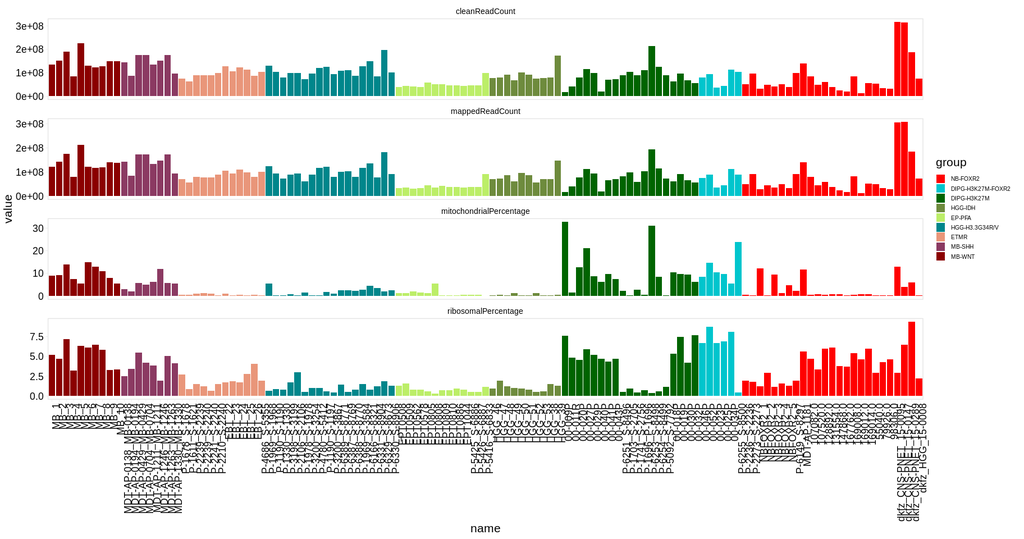

```r
align_stats <- align_stats %>%
    left_join(info_samples, by = c("name" = "Nickname")) %>%
    separate(mitochondrialPercentage, sep = "%", into = "mitochondrialPercentage") %>%
    separate(ribosomalPercentage,     sep = "%", into = "ribosomalPercentage") %>%
    mutate(mitochondrialPercentage = as.numeric(mitochondrialPercentage),
           ribosomalPercentage     = as.numeric(ribosomalPercentage))

align_stats %>%
    select(name, group, cleanReadCount, mappedReadCount,
           mitochondrialPercentage, ribosomalPercentage) %>%
    gather(stat, value, 3:6) %>%
    mutate(group = factor(group, levels = names(palette_groups))) %>%
    arrange(desc(group)) %>%
    mutate(name = factor(name, levels = unique(.$name))) %>%
    ggplot(aes(x = name, y = value)) +
    geom_bar(aes(fill = group), stat = "identity") +
    scale_fill_manual(values = palette_groups) +
    facet_wrap(~ stat, scales = "free_y", ncol = 1) +
    rotate_x()
```

### 5.2.1 TABLE: Human bulk QC

Export a supplementary table for human bulk RNA-seq QC.

```r
align_stats %>%
    select(-ID, -group) %>%
    dplyr::rename(ID = name) %>%
    dplyr::relocate(Group, .after = 1) %>%
    rr_write_tsv(glue("{out}/TABLE_bulk_stats.tsv"),
                 "QC stats for bulk RNAseq data")
```

```
## ...writing description of TABLE_bulk_stats.tsv to public/output/03/TABLE_bulk_stats.desc
```

## 5.3 PCA

```r
# load the counts saved by the pipeline
load(here("data/RNAseq/pipeline_l3/2023-05-test_pbt/.counts.RData"))

# get highly-variable genes
var_idx <- apply(counts$norm$Ensembl.ensGene.exon, 1, var) %>%
    order(decreasing = TRUE) %>%
    .[1:1000]

pbt_counts_vst_hvg <- counts$vst$Ensembl.ensGene.exon[var_idx, ]

pca       <- prcomp(t(pbt_counts_vst_hvg))
variance  <- round(pca$sdev^2 / sum(pca$sdev^2), 3) * 100

pca_df <- data.frame(Dim1 = pca$x[, 1],
                     Dim2 = pca$x[, 2],
                     Sample = colnames(pbt_counts_vst_hvg))

p1 <- pca_df %>%
    left_join(meta_bulk, by = c("Sample" = "ID")) %>%
    ggplot(aes(x = Dim1, y = Dim2)) +
    geom_point(aes(colour = Group), alpha = 0.7, size = 2) +
    scale_color_manual(values = palette_groups) +
    xlab(paste0("PC1 (", variance[1], "%)")) +
    ylab(paste0("PC2 (", variance[2], "%)")) +
    color_legend_ncol(2) +
    ggtitle("PCA")

p2 <- pca_df %>%
    left_join(meta_bulk, by = c("Sample" = "ID")) %>%
    ggplot(aes(x = Dim1, y = Dim2)) +
    geom_point(aes(colour = Source), alpha = 0.7, size = 2) +
    xlab(paste0("PC1 (", variance[1], "%)")) +
    ylab(paste0("PC2 (", variance[2], "%)")) +
    color_legend_ncol(2) +
    ggtitle("PCA")
```

Coloured by QC stats:

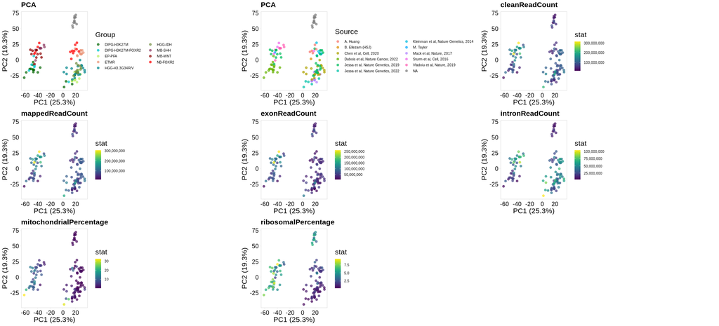

```r
pca_with_align_stats <- pca_df %>%
    left_join(info_samples, by = c("Sample" = "Nickname")) %>%
    left_join(align_stats, by = c("Sample" = "name", "Group" = "group"))

pca_stat_plots <- list()

stats <- c("cleanReadCount",
           "mappedReadCount",
           "exonReadCount",
           "intronReadCount",
           "mitochondrialPercentage",
           "ribosomalPercentage")

for (i in seq_along(stats)) {

    df <- pca_with_align_stats
    df$stat <- df[, stats[i]]

    gg <- df %>%
        arrange(stat) %>%
        ggplot(aes(x = Dim1, y = Dim2)) +
        geom_point(aes(colour = stat), alpha = 0.7, size = 2) +
        scale_colour_viridis(labels = comma) +
        xlab(paste0("PC1 (", variance[1], "%)")) +
        ylab(paste0("PC2 (", variance[2], "%)")) +
        ggtitle(stats[i])

    pca_stat_plots[[i]] <- gg

}

plot_grid(plotlist = c(list(p1, p2), pca_stat_plots), align = "hv", axis = "rltb", ncol = 3)
```

## 5.4 FOXR2 expression

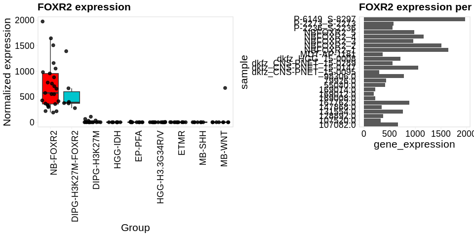

```r
p1 <- counts_foxr2 %>%
    ggplot(aes(x = Group, y = gene_expression)) +
    geom_boxplot(aes(fill = Group), outlier.shape = NA) +
    geom_jitter(size = 2, alpha = 0.8) +
    scale_fill_manual(values = palette_groups)  +
    ylab("Normalized expression") + xlab("Group") +
    no_legend() + rotate_x() +
    ggtitle("FOXR2 expression")

p2 <- counts_foxr2 %>%
    filter(Group == "NB-FOXR2") %>%
    ggplot(aes(x = sample, y = gene_expression)) +
    geom_bar(stat = "identity") +
    coord_flip() +
    ggtitle("FOXR2 expression per sample")

plot_grid(p1, p2, nrow = 1, align = "h", axis = "tb")
```

Check FOXR2 expression across samples:

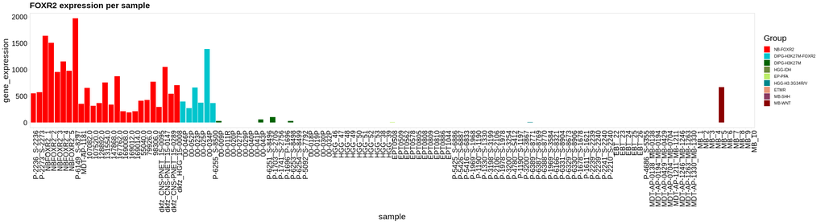

```r
counts_foxr2 %>%
    arrange(Group) %>%
    mutate(sample = factor(sample, levels = unique(.$sample))) %>%
    ggplot(aes(x = sample, y = gene_expression)) +
    geom_bar(stat = "identity", aes(fill = Group)) +
    scale_fill_manual(values = palette_groups) +
    ggtitle("FOXR2 expression per sample") +
    rotate_x()
```

## 5.5 MDM4 expression

The ubiquitous loss of chr1 in NB-FOXR2 may lead to overexpression of MDM2/MDM4, which phenocopies p53 loss in the tumor context ([Girish et al. *Science* 2023](https://pubmed.ncbi.nlm.nih.gov/37410869/)).

Here, we investigate this possibility by comparing expression of MDM4 across the bulk intracranial tumor cohort.

```r
# load counts for MDM genes
counts_MDM <- extract_pipeline_counts(path = here("data/RNAseq/pipeline_l3/2023-05-test_pbt/counts/Ensembl.ensGene.exon.norm.tsv.gz"),
                                        goi = c("MDM4")) %>%
    left_join(info_samples, by = c("sample" = "Nickname")) %>%
    mutate(Group = factor(Group, levels = names(palette_groups)))
```

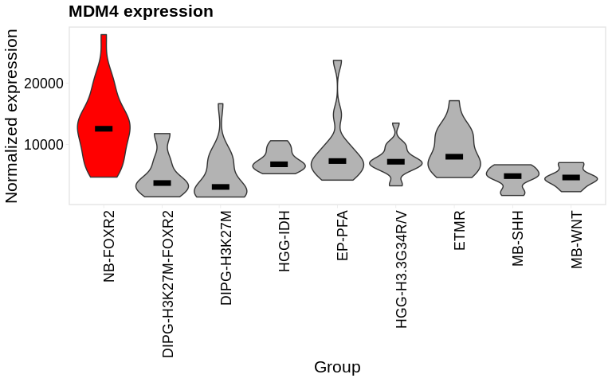

```r
palette_highlight_nbfoxr2 <- rep("grey70", length(palette_groups))
names(palette_highlight_nbfoxr2) <- names(palette_groups)
palette_highlight_nbfoxr2[which(names(palette_highlight_nbfoxr2) == "NB-FOXR2")] <- "red"

counts_MDM %>%
    filter(gene_symbol == "MDM4") %>%
    ggplot(aes(x = Group, y = gene_expression, fill = Group)) +
    geom_violin(scale = "width") +
    scale_fill_manual(values = palette_highlight_nbfoxr2)  +
    ylab("Normalized expression") + xlab("Group") +
    no_legend() + rotate_x() +
    ggtitle("MDM4 expression") +
    stat_summary(fun.y=median, geom="crossbar", size=1, color="black", aes(width = 0.3))
```

# 6 Extra-cranial neuroblastoma

## 6.1 Loading and data wrangling

Load processed bulk RNAseq counts from [Gartlgruber et al, Nature Cancer, 2020](https://www.nature.com/articles/s43018-020-00145-w#Abs1).

The data was downloaded via their shiny app (https://nbseb087.dkfz.de/project_NB_SE_viz/).

```r
gartlgruber_meta <- readRDS(here("data/RNAseq/external_data/Gartlgruber_NatCancer_2021/annotation_tumor_RNAseq.rds"))
length(unique(gartlgruber_meta$ProjectID))
```

```
## [1] 579
```

```r
# load annotation of ChIPseq data to look for overlapping samples
gartlgruber_meta_chip <- readRDS(here("data/ChIPseq/external_data/Gartlgruber_NatCancer_2021/annotation_tumor_ChIPseq.rds"))
gartlgruber_meta <- gartlgruber_meta %>%
    left_join(gartlgruber_meta_chip, by = c("ProjectID", "MYCN", "Stage",
                                            "Age", "Risk", "Relapse"))

gartlgruber_counts <- readRDS(here("data/RNAseq/external_data/Gartlgruber_NatCancer_2021/tumor_RNAseq_Counts_Matrix.rds"))
dim(gartlgruber_counts)
```

```
## [1] 57820   579
```

```r
gartlgruber_counts[1:5, 1:5]
```

```
##                              NSP001-PT01 NSP002-PT01 NSP003-RM01 NSP005-RT01
## ENSG00000223972.4|DDX11L1              4           0           0           3
## ENSG00000227232.4|WASH7P             431        1348        1242        1117
## ENSG00000243485.2|MIR1302-11           0           0           0           0
## ENSG00000237613.2|FAM138A              0           0           0           0
## ENSG00000268020.2|OR4G4P               0           0           0           0
##                              NSP006-RM01
## ENSG00000223972.4|DDX11L1              1
## ENSG00000227232.4|WASH7P            1391
## ENSG00000243485.2|MIR1302-11           0
## ENSG00000237613.2|FAM138A              0
## ENSG00000268020.2|OR4G4P               0
```

Normalize and reformat:

```r
# normalize using DESeq2
dds <- DESeqDataSetFromMatrix(countData = gartlgruber_counts,
                              colData   = gartlgruber_meta,
                              design    = ~ 1)
dds <- DESeq(dds)
```

```
## -- replacing outliers and refitting for 6774 genes
## -- DESeq argument 'minReplicatesForReplace' = 7
## -- original counts are preserved in counts(dds)
```

```r
ecnb_counts_norm <- counts(dds, normalized = TRUE)
vsd  <- vst(dds)
ecnb_counts_vst <- assay(vsd)
```

Convert to tidy format with metadata:

```r
ecnb_counts_tidy <- ecnb_counts_norm %>%
    as.data.frame() %>%
    tibble::rownames_to_column(var = "id") %>%
    separate(id, into = c("ens_id.x", "gene_symbol"), sep = "\\|") %>%
    separate(ens_id.x, into = c("ens_id", "drop"), sep = "\\.") %>%
    select(-drop) %>%
    gather(sample, gene_expression, 3:ncol(.)) %>%
    left_join(gartlgruber_meta, by = c("sample" = "ProjectID"))

save(ecnb_counts_tidy, ecnb_counts_norm, ecnb_counts_vst, file = glue("{out}/Gartlgruber_et_al_counts.Rda"))
```

# 7 Reproducibility

This document was last rendered on:

```
## 2024-11-01 11:50:05
```

The git repository and last commit:

```
## Local:    main /project/kleinman/bhavyaa.chandarana/from_hydra/2023-05-NB-FOXR2/public
## Remote:   main @ origin (https://github.com/fungenomics/NB-FOXR2.git)
## Head:     [0e89693] 2024-09-12: Initial commit
```

The random seed was set with `set.seed(100)`

A project of the Kleinman Lab at McGill University, using the [rr](https://github.com/sjessa/rr/) reproducible research template.